# Cyclistic_202401 TO 202502

rjld

2025-03-30

## PREREQUISITES

Please install these packages first before running: install.packages(‘tidyverse’) install.packages(‘lubridate’) install.packages(‘ggplot2’) #### Loading necessary libraries packages

```r
library(tidyverse)
library(dplyr)
library(lubridate)
library(vroom)
```

```r
library(readr)
library(ggplot2)
```

#### List all datasets

```r
csv_files <- list.files("D:/Users/rjlde/Documents/+STUDY FILES+/2025 CASE STUDIES/CASE STUDY 1/RPROJ/10014985/2025_CS01_Cyclistic/CSV", pattern = "*.csv", full.names = TRUE)
```

#### combine CSV data

```r
df_merged <- csv_files %>%
  lapply(read_csv, col_types = cols()) %>%
  bind_rows()
```

#### CONVERT DATA TYPES to datetime

```r
df_merged_converted <- df_merged %>%
  mutate(
    started_at = ymd_hms(started_at, tz = "UTC"),   # Convert to datetime
    ended_at = ymd_hms(ended_at, tz = "UTC"),       # Convert to datetime
    day_of_the_week = as.integer(day_of_the_week)   # Convert to integer
  )
```

### FILTER DATE RANGE

```r
df_merged_filtered <- df_merged_converted %>%
  mutate(date_only = as.Date(started_at))
```

```r
df_merged_filtered <- df_merged_filtered %>%
    filter(date_only >= '2024-01-01' & date_only <= '2025-02-28')
```

check:

```r
df_merged_filtered %>%
   mutate(month = floor_date(date_only, "month")) %>%
  group_by(month) %>%
 summarise(count = n()) %>%
  arrange(month)
```

```
## # A tibble: 14 × 2
##    month       count
##    <date>      <int>
##  1 2024-01-01 144488
##  2 2024-02-01 222818
##  3 2024-03-01 301185
##  4 2024-04-01 414358
##  5 2024-05-01 608662
##  6 2024-06-01 599989
##  7 2024-07-01 615975
##  8 2024-08-01 620133
##  9 2024-09-01 618224
## 10 2024-10-01 615685
## 11 2024-11-01 334721
## 12 2024-12-01 178282
## 13 2025-01-01 138587
## 14 2025-02-01 151798
```

#### SAVE AS CSV FILE MERGED DATASETS

```r
write_csv(df_merged_filtered, "D:/Users/rjlde/Documents/+STUDY FILES+/2025 CASE STUDIES/CASE STUDY 1/RPROJ/10014985/2025_CS01_Cyclistic/df_merged_filtered.csv")
```

## LOAD & CHECK CLEAN DATA FROM MERGED CSV FILE

#### use new file a sdataset

```r
df_cleaned <- read_csv("D:/Users/rjlde/Documents/+STUDY FILES+/2025 CASE STUDIES/CASE STUDY 1/RPROJ/10014985/2025_CS01_Cyclistic/df_merged_filtered.csv")
```

#### remove duplicates

```r
df_cleaned_distinct <- df_cleaned %>%
  distinct(ride_id, .keep_all = TRUE)  # Keeps only one row per unique ride_id
```

#### cleaning ride_length

```r
library(dplyr)

# Step 1: Remove rows where ride_length is NA and update df_cleaned_distinct
df_cleaned_distinct <- df_cleaned_distinct %>%
  filter(!is.na(ride_length))  # Remove rows with NA values in ride_length
```

#### Basic Data Structure Check

Check integrity of table

```r
glimpse(df_cleaned_distinct)  # Overview of columns & types
```

```
## Rows: 5,564,691
## Columns: 16
## $ ride_id            <chr> "C1D650626C8C899A", "EECD38BDB25BFCB0", "F4A9CE7806…
## $ rideable_type      <chr> "electric_bike", "electric_bike", "electric_bike", …
## $ started_at         <dttm> 2024-01-12 15:30:27, 2024-01-08 15:45:46, 2024-01-…
## $ ended_at           <dttm> 2024-01-12 15:37:59, 2024-01-08 15:52:59, 2024-01-…
## $ start_station_name <chr> "Wells St & Elm St", "Wells St & Elm St", "Wells St…
## $ start_station_id   <chr> "KA1504000135", "KA1504000135", "KA1504000135", "TA…
## $ end_station_name   <chr> "Kingsbury St & Kinzie St", "Kingsbury St & Kinzie …
## $ end_station_id     <chr> "KA1503000043", "KA1503000043", "KA1503000043", "13…
## $ start_lat          <dbl> 41.9033, 41.9029, 41.9030, 41.8843, 41.9488, 41.903…
## $ start_lng          <dbl> -87.6347, -87.6344, -87.6345, -87.6340, -87.6753, -…
## $ end_lat            <dbl> 41.8892, 41.8892, 41.8892, 41.9218, 41.8892, 41.889…
## $ end_lng            <dbl> -87.6385, -87.6385, -87.6385, -87.6441, -87.6385, -…
## $ member_casual      <chr> "member", "member", "member", "member", "member", "…
## $ ride_length        <time> 00:07:32, 00:07:13, 00:08:00, 00:29:49, 00:26:12, …
## $ day_of_the_week    <dbl> 6, 2, 7, 2, 4, 1, 6, 5, 2, 4, 4, 4, 4, 6, 1, 4, 7, …
## $ date_only          <date> 2024-01-12, 2024-01-08, 2024-01-27, 2024-01-29, 20…
```

```r
head(df_cleaned_distinct)     # First few rows
```

```
## # A tibble: 6 × 16
##   ride_id          rideable_type started_at          ended_at
##   <chr>            <chr>         <dttm>              <dttm>
## 1 C1D650626C8C899A electric_bike 2024-01-12 15:30:27 2024-01-12 15:37:59
## 2 EECD38BDB25BFCB0 electric_bike 2024-01-08 15:45:46 2024-01-08 15:52:59
## 3 F4A9CE78061F17F7 electric_bike 2024-01-27 12:27:19 2024-01-27 12:35:19
## 4 0A0D9E15EE50B171 classic_bike  2024-01-29 16:26:17 2024-01-29 16:56:06
## 5 33FFC9805E3EFF9A classic_bike  2024-01-31 05:43:23 2024-01-31 06:09:35
## 6 C96080812CD285C5 classic_bike  2024-01-07 11:21:24 2024-01-07 11:30:03
## # ℹ 12 more variables: start_station_name <chr>, start_station_id <chr>,
## #   end_station_name <chr>, end_station_id <chr>, start_lat <dbl>,
## #   start_lng <dbl>, end_lat <dbl>, end_lng <dbl>, member_casual <chr>,
## #   ride_length <time>, day_of_the_week <dbl>, date_only <date>
```

```r
summary(df_cleaned_distinct)  # Summary statistics
```

```
##    ride_id          rideable_type        started_at
##  Length:5564691     Length:5564691     Min.   :2024-01-01 00:00:39.00
##  Class :character   Class :character   1st Qu.:2024-05-17 20:48:04.50
##  Mode  :character   Mode  :character   Median :2024-07-25 20:37:41.00
##                                        Mean   :2024-07-25 11:17:58.63
##                                        3rd Qu.:2024-10-02 10:16:38.50
##                                        Max.   :2025-02-28 23:56:09.00
##     ended_at                      start_station_name start_station_id
##  Min.   :2024-01-01 00:04:20.00   Length:5564691     Length:5564691
##  1st Qu.:2024-05-17 21:03:49.00   Class :character   Class :character
##  Median :2024-07-25 20:55:54.00   Mode  :character   Mode  :character
##  Mean   :2024-07-25 11:33:09.72
##  3rd Qu.:2024-10-02 10:29:40.50
##  Max.   :2025-02-28 23:57:52.00
##  end_station_name   end_station_id       start_lat       start_lng
##  Length:5564691     Length:5564691     Min.   :41.64   Min.   :-87.91
##  Class :character   Class :character   1st Qu.:41.88   1st Qu.:-87.66
##  Mode  :character   Mode  :character   Median :41.90   Median :-87.64
##                                        Mean   :41.90   Mean   :-87.65
##                                        3rd Qu.:41.93   3rd Qu.:-87.63
##                                        Max.   :42.07   Max.   :-87.52
##     end_lat         end_lng        member_casual      ride_length
##  Min.   :30.02   Min.   :-144.05   Length:5564691     Length:5564691
##  1st Qu.:41.88   1st Qu.: -87.66   Class :character   Class1:hms
##  Median :41.90   Median : -87.64   Mode  :character   Class2:difftime
##  Mean   :41.90   Mean   : -87.65                      Mode  :numeric
##  3rd Qu.:41.93   3rd Qu.: -87.63
##  Max.   :87.96   Max.   : 152.53
##  day_of_the_week   date_only
##  Min.   :1.000   Min.   :2024-01-01
##  1st Qu.:2.000   1st Qu.:2024-05-17
##  Median :4.000   Median :2024-07-25
##  Mean   :4.093   Mean   :2024-07-24
##  3rd Qu.:6.000   3rd Qu.:2024-10-02
##  Max.   :7.000   Max.   :2025-02-28
```

#### Check Missing Values

```r
colSums(is.na(df_cleaned_distinct))
```

```
##            ride_id      rideable_type         started_at           ended_at
##                  0                  0                  0                  0
## start_station_name   start_station_id   end_station_name     end_station_id
##             948067             948067             900034             900034
##          start_lat          start_lng            end_lat            end_lng
##                  0                  0                  0                  0
##      member_casual        ride_length    day_of_the_week          date_only
##                  0                  0                  0                  0
```

## ANALYSIS VISUALIZATION

If all is well for steps above, continue with analysis.

### Total Count of Trips by User Type 202401 to 202502

Determine total # of trips for span of 202401 to 202502 dataset. Show % and group by member_casual

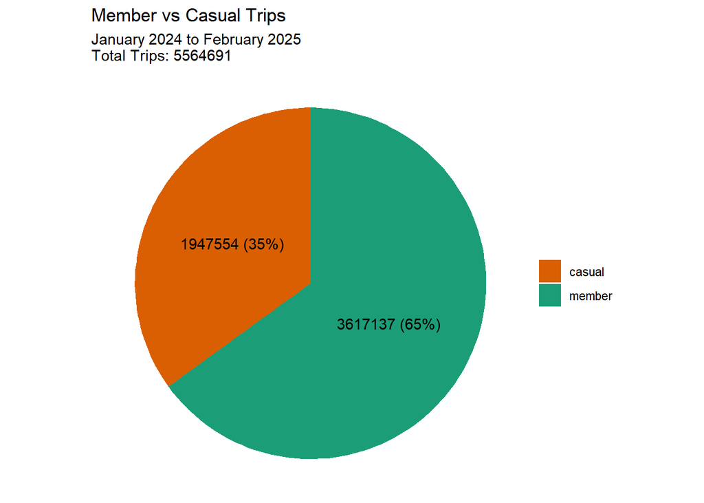

```r
library(ggplot2)

# Count trips by user type
overall_counts <- df_cleaned_distinct %>%
  group_by(member_casual) %>%
  summarise(count = n()) %>%
  mutate(percentage = round((count / sum(count)) * 100, 1))
# Calculate total trips
total_trips_overall <- sum(overall_counts$count)
# Pie chart
ggplot(overall_counts, aes(x = "", y = count, fill = member_casual)) +
  geom_bar(stat = "identity", width = 1) +
  coord_polar("y", start = 0) +
  geom_text(aes(label = paste0(count, " (", percentage, "%)")),
            position = position_stack(vjust = 0.5)) +
  labs(title = "Member vs Casual Trips",
       subtitle = paste("January 2024 to February 2025\nTotal Trips:", total_trips_overall)) +
  theme_void() +
  theme(legend.title = element_blank()) +
  scale_fill_manual(values = c("member" = "#1B9E77",  # Green for members
                               "casual" = "#D95F02")) # Orange for casual users
```

### Total Count of Trips by User Type 202401 to 202412 (1 year)

Determine total # of trips for span of 202401 to 202412 dataset. Show % and group by member_casual

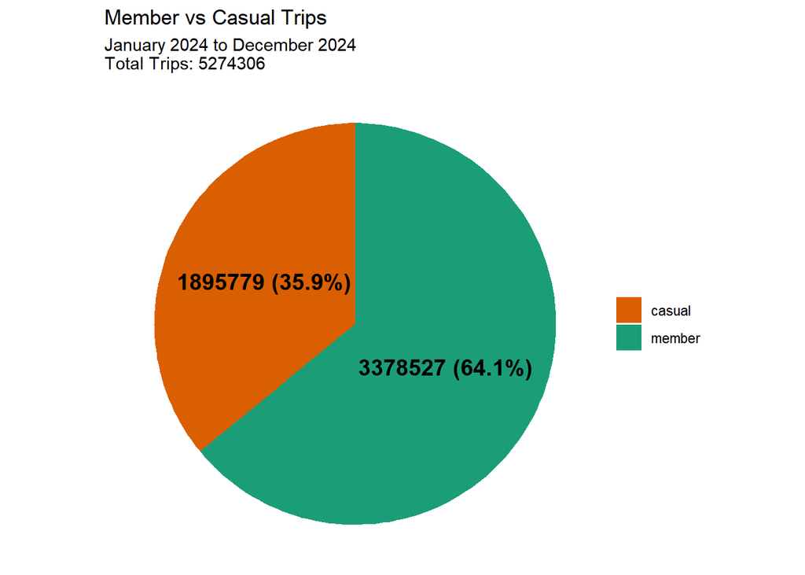

```r
library(ggplot2)

# Filter data for 2024
df_2024 <- df_cleaned_distinct %>%
  filter(year(started_at) == 2024)

# Count trips by user type
yearly_counts <- df_2024 %>%
  group_by(member_casual) %>%
  summarise(count = n()) %>%
  mutate(percentage = round((count / sum(count)) * 100, 1))

# Calculate total trips for 2024
total_trips_2024 <- sum(yearly_counts$count)

# Pie chart for 2024
ggplot(yearly_counts, aes(x = "", y = count, fill = member_casual)) +
  geom_bar(stat = "identity", width = 1) +
  coord_polar("y", start = 0) +
  geom_text(aes(label = paste0(count, " (", percentage, "%)")),
            position = position_stack(vjust = 0.5), size = 5, fontface = "bold") +
  labs(title = "Member vs Casual Trips",
       subtitle = paste("January 2024 to December 2024\nTotal Trips:", total_trips_2024)) +  # ✅ Updated caption
  theme_void() +
  theme(legend.title = element_blank()) +
  scale_fill_manual(values = c("member" = "#1B9E77",  # Green for members
                               "casual" = "#D95F02")) # Orange for casual users
```

### TIME-BASED ANALYSIS

#### When Do Members VS Causal Cyclists Travel the Most? Monthly (January 2024 to February 2025)

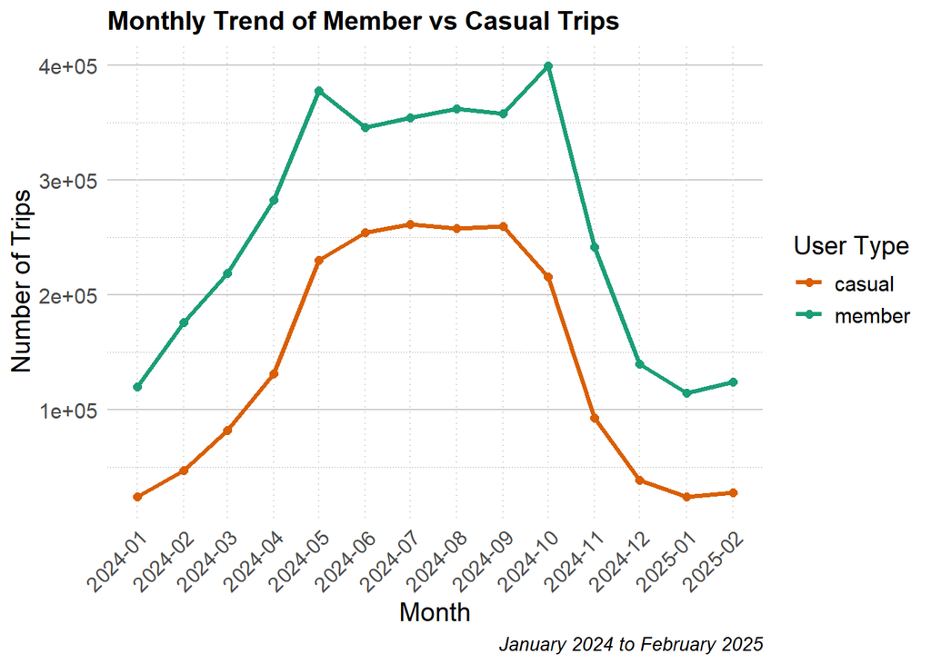

```r
library(ggplot2)
# Aggregate monthly trip counts
monthly_trend <- df_cleaned_distinct %>%
  mutate(month = format(started_at, "%Y-%m")) %>%  # Extract year-month
  group_by(month, member_casual) %>%
  summarise(trips = n(), .groups = "drop")
# Convert month to date format for correct ordering
monthly_trend$month <- as.Date(paste0(monthly_trend$month, "-01"))
# Updated custom theme with vertical grid lines
custom_theme_v2 <- custom_theme +
  theme(panel.grid.major.x = element_line(color = "grey85", linetype = "dotted"))  # Add faint vertical grid lines
# Plot trend line with improved alignment and custom colors
ggplot(monthly_trend, aes(x = month, y = trips, color = member_casual, group = member_casual)) +
  geom_line(linewidth = 1.2) +  # Trend line
  geom_point(size = 2) +  # Add points for clarity
  scale_x_date(date_labels = "%Y-%m", date_breaks = "1 month") +  # Format x-axis labels
  scale_color_manual(values = custom_colors) +  # Apply custom colors
  labs(title = "Monthly Trend of Member vs Casual Trips",
       caption = "January 2024 to February 2025",
       x = "Month",
       y = "Number of Trips",
       color = "User Type") +
  custom_theme_v2 +  # Apply updated theme
  theme(axis.text.x = element_text(angle = 45, hjust = 1))  # Rotate x-axis labels
```

#### When Do Members VS Causal Cyclists Travel the Most? Day-of the-week (January 2024 to February 2025)

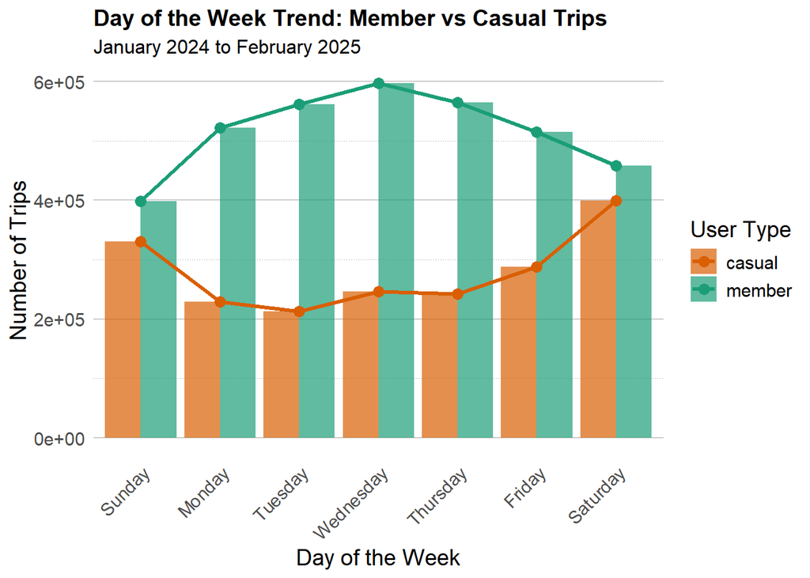

```r
library(ggplot2)

# Define weekday labels (1 = Sunday, 7 = Saturday)
weekday_labels <- c("1" = "Sunday", "2" = "Monday", "3" = "Tuesday",
                    "4" = "Wednesday", "5" = "Thursday", "6" = "Friday", "7" = "Saturday")

# Aggregate trips by day of the week
day_trend <- df_cleaned_distinct %>%
  group_by(day_of_the_week, member_casual) %>%
  summarise(trips = n(), .groups = "drop") %>%
  mutate(day_of_the_week = factor(day_of_the_week,
                                  levels = 1:7,  # Ensure correct order
                                  labels = weekday_labels))  # Convert to names

# Plot with bars + trendline
ggplot(day_trend, aes(x = day_of_the_week, y = trips, fill = member_casual)) +
  geom_bar(stat = "identity", position = "dodge", alpha = 0.7) +  # Bars with transparency
  geom_line(aes(group = member_casual, color = member_casual),
            linewidth = 1.2) +  # Trendline overlay
  geom_point(aes(color = member_casual), size = 3) +  # Highlight data points
  scale_fill_manual(values = custom_colors) +  # Bar colors
  scale_color_manual(values = custom_colors) +  # Line colors
  labs(title = "Day of the Week Trend: Member vs Casual Trips",
       subtitle = "January 2024 to February 2025",
       x = "Day of the Week",
       y = "Number of Trips",
       fill = "User Type",
       color = "User Type") +
  custom_theme +
  theme(axis.text.x = element_text(angle = 45, hjust = 1))  # Rotate labels for readability
```

#### When Do Members VS Causal Cyclists Travel the Most? Hour-of-the-Day Total Number of Trips (January 2024 to February 2025)

Determining hour of the day with highest count of trips

[figure not shown]

```r
# Convert datetime column to extract hour
df_cleaned_distinct$hour <- hour(df_cleaned_distinct$started_at)  # Extract hour from 'started_at' column

# Count trips per hour
hourly_trips <- df_cleaned_distinct %>%
  group_by(hour) %>%
  summarise(count = n(), .groups = "drop")

# Plot trips by hour
ggplot(hourly_trips, aes(x = factor(hour), y = count, fill = hour)) +
  geom_bar(stat = "identity") +
  scale_y_continuous(
    breaks = seq(0, max(hourly_trips), by = 1500),
    minor_breaks = seq(0, max(hourly_trips), by = 500)  # Try smaller increments
  ) +

# Custom color scale: Night (Blue) → Day (Yellow/Orange) → Night (Blue)
  scale_fill_gradientn(colors = c("#1B3764", "#3F51B5", "#FFEB3B", "#FB8C00", "#3F51B5", "#1B3764")) +

# Labels and styling
  labs(x = "Hour of the Day",
       y = "Number of Trips",
       title = "Total Number of Trips by Hour-of-the-Day",
       caption ="January 2024 to February 2025") +
  custom_theme +
  theme(legend.position = "none")  # Remove legend (since it's a time progression)
```

#### When Do Members VS Causal Cyclists Travel the Most? Hour-of-the-Day Total Number of Trips (January 2024 to February 2025)

Determining hour of the day with highest count of trips separated by member_casual

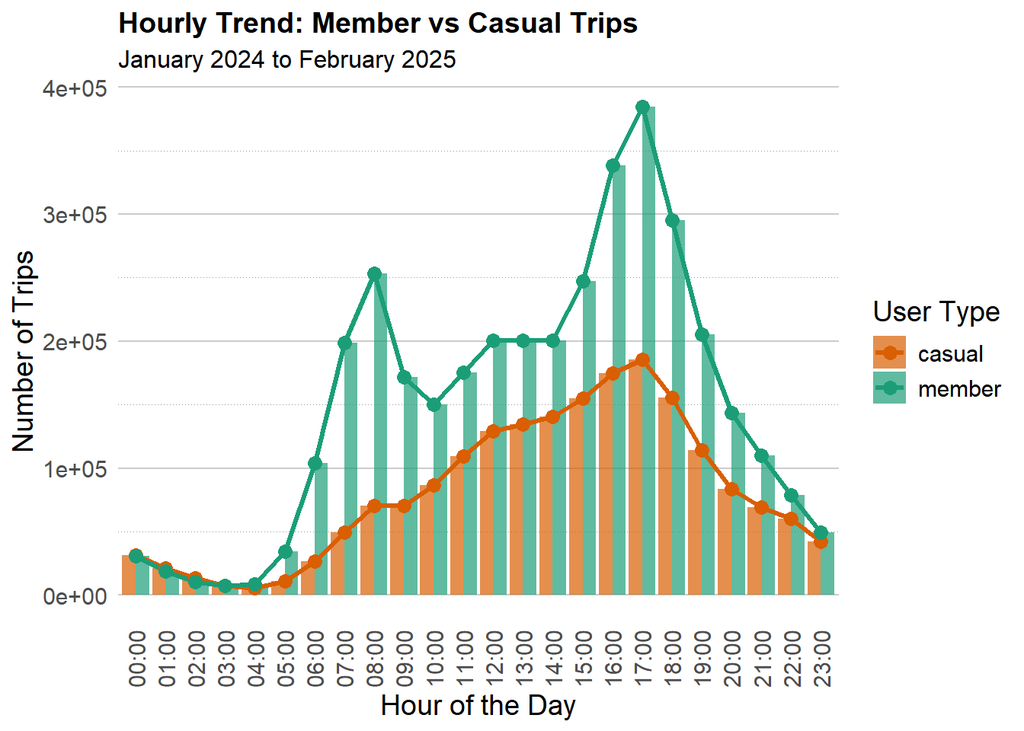

```r
library(ggplot2)

# Extract hour and format as "HH:00"
df_cleaned_distinct <- df_cleaned_distinct %>%
  mutate(hour = factor(hour(started_at), levels = 0:23, labels = sprintf("%02d:00", 0:23)))

# Aggregate trips by hour
hourly_trend <- df_cleaned_distinct %>%
  group_by(hour, member_casual) %>%
  summarise(trips = n(), .groups = "drop")

# Plot with bars + trendline
ggplot(hourly_trend, aes(x = hour, y = trips, fill = member_casual)) +
  geom_bar(stat = "identity", position = "dodge", alpha = 0.7) +  # Bars for hourly count
  geom_line(aes(group = member_casual, color = member_casual),
            linewidth = 1.2) +  # Trendline overlay
  geom_point(aes(color = member_casual), size = 3) +  # Highlight data points
  scale_fill_manual(values = custom_colors) +  # Bar colors
  scale_color_manual(values = custom_colors) +  # Line colors
  labs(title = "Hourly Trend: Member vs Casual Trips",
       subtitle = "January 2024 to February 2025",
       x = "Hour of the Day",
       y = "Number of Trips",
       fill = "User Type",
       color = "User Type") +
  custom_theme +
  theme(axis.text.x = element_text(angle = 90, vjust = 0.5, hjust = 1))  # Rotate labels to 90 degrees
```

### DURATION-BASED ANALYSIS

#####BOXPLOT: RIDE LENGTH, MEMBER VS CASUAL, NUMBER OF TRIPS

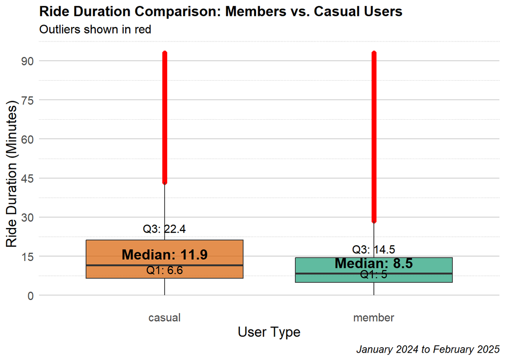

```r
# Calculate summary statistics (median, Q1, Q3) for annotation
summary_stats <- df_cleaned_distinct %>%
  group_by(member_casual) %>%
  summarise(
    Q1 = quantile(as.numeric(ride_length) / 60, 0.25, na.rm = TRUE),
    Median = median(as.numeric(ride_length) / 60, na.rm = TRUE),
    Q3 = quantile(as.numeric(ride_length) / 60, 0.75, na.rm = TRUE)
  )

ggplot(df_cleaned_distinct, aes(x = member_casual, y = as.numeric(ride_length) / 60, fill = member_casual)) +
  geom_boxplot(outlier.colour = "red", outlier.shape = 16, outlier.size = 2, alpha = 0.7) +
  geom_text(data = summary_stats, aes(x = member_casual, y = Median, label = paste("Median:", round(Median, 1))),
            vjust = -0.5, fontface = "bold", color = "black", size = 5) +
  geom_text(data = summary_stats, aes(x = member_casual, y = Q1, label = paste("Q1:", round(Q1, 1))),
            vjust = -0.5, color = "black", size = 4) +
  geom_text(data = summary_stats, aes(x = member_casual, y = Q3, label = paste("Q3:", round(Q3, 1))),
            vjust = -0.5, color = "black", size = 4) +
  scale_y_continuous(
    name = "Ride Duration (Minutes)",
    limits = c(0, quantile(as.numeric(df_cleaned_distinct$ride_length) / 60, 0.99, na.rm = TRUE)),
    breaks = seq(0, quantile(as.numeric(df_cleaned_distinct$ride_length) / 60, 0.99, na.rm = TRUE), by = 15)
  ) +
  scale_x_discrete(name = "User Type") +
  scale_fill_manual(values = custom_colors) +
  labs(
    title = "Ride Duration Comparison: Members vs. Casual Users",
    subtitle = "Outliers shown in red",
    caption = "January 2024 to February 2025"
  ) +
  custom_theme +
  theme(legend.position = "none")
```

####GRAPH: AVERAGE RIDE_LENGTH BY DAY-OF-THE-WEEK, MEMBER VS CASUAL

[figure not shown]

```r
library(tidyverse)
library(lubridate)

# Step 1: Convert ride_length to minutes and create a new column ride_length_minutes
df_cleaned_distinct <- df_cleaned_distinct %>%
  mutate(ride_length_sec = as.numeric(ride_length),  # Convert to seconds
         ride_length_minutes = ride_length_sec / 60)  # Convert to minutes

# Step 2: Create a new column day_of_the_week_text to convert day_of_the_week (1 to 7) into text
df_cleaned_distinct <- df_cleaned_distinct %>%
  mutate(day_of_the_week_text = factor(day_of_the_week,
                                       levels = 1:7,
                                       labels = c("Sunday", "Monday", "Tuesday", "Wednesday", "Thursday", "Friday", "Saturday")))

# Step 3: Remove NA values in ride_length_minutes (if any)
df_cleaned_distinct <- df_cleaned_distinct %>%
  filter(!is.na(ride_length_minutes))

# Step 4: Group by day_of_the_week_text and member_casual and calculate the average ride_length_minutes
df_avg_ride <- df_cleaned_distinct %>%
  group_by(day_of_the_week_text, member_casual) %>%
  summarise(avg_ride_length_minutes = mean(ride_length_minutes), .groups = "drop")

# Step 5: Create the ggplot
ggplot(df_avg_ride, aes(x = day_of_the_week_text, y = avg_ride_length_minutes, fill = member_casual)) +
  geom_bar(stat = "identity", position = "dodge") +
  scale_fill_manual(values = c("member" = "#1B9E77", "casual" = "#D95F02")) +  # Custom colors for member/casual
  labs(title = "Average Ride Length by Day of the Week",
       x = "Day of the Week",
       y = "Average Ride Length (Minutes)",
       caption = "Data: January 2024 to January 2025") +
  theme_minimal() +
  theme(
    text = element_text(size = 14),  # Increase overall text size
    panel.grid.major.x = element_blank(),
    panel.grid.minor.x = element_blank(),
    panel.grid.major.y = element_line(color = "grey80"),
    panel.grid.minor.y = element_line(color = "grey60", linetype = "dotted"),
    panel.background = element_rect(fill = "transparent", color = NA),
    plot.title = element_text(size = 14, face = "bold"),
    plot.subtitle = element_text(size = 12),
    plot.caption = element_text(size = 10, face = "italic")
  )
```

#### table OF RIDE LENGTH SUMMARY

Also referencing results from boxplot earlier

```r
# Calculate summary statistics (median, Q1, Q3) for annotation
summary_stats <- df_cleaned_distinct %>%
  group_by(member_casual) %>%
  summarise(
    Q1 = quantile(as.numeric(ride_length) / 60, 0.25, na.rm = TRUE),
    Median = median(as.numeric(ride_length) / 60, na.rm = TRUE),
    Q3 = quantile(as.numeric(ride_length) / 60, 0.75, na.rm = TRUE),
    IQR = Q3 - Q1  # Interquartile Range
  )

# Define a threshold to exclude extreme outliers
threshold_upper <- summary_stats$Q3 + 1.5 * summary_stats$IQR
threshold_lower <- summary_stats$Q1 - 1.5 * summary_stats$IQR

# Filter out outliers from df_cleaned_distinct
df_filtered <- df_cleaned_distinct %>%
  filter(
    (as.numeric(ride_length) / 60) <= threshold_upper[match(member_casual, summary_stats$member_casual)] &
    (as.numeric(ride_length) / 60) >= threshold_lower[match(member_casual, summary_stats$member_casual)]
  )

# Calculate ride statistics (average, max, min) excluding outliers
ride_stats <- df_filtered %>%
  group_by(member_casual) %>%
  summarise(
    avg_ride_length = mean(as.numeric(ride_length) / 60, na.rm = TRUE),
    max_ride_length = max(as.numeric(ride_length) / 60, na.rm = TRUE),
    min_ride_length = min(as.numeric(ride_length) / 60, na.rm = TRUE)
  )

# Calculate overall stats by combining both 'member' and 'casual'
overall_stats <- df_filtered %>%
  summarise(
    avg_ride_length = mean(as.numeric(ride_length) / 60, na.rm = TRUE),
    max_ride_length = max(as.numeric(ride_length) / 60, na.rm = TRUE),
    min_ride_length = min(as.numeric(ride_length) / 60, na.rm = TRUE)
  )

# Add overall statistics to the ride_stats table
ride_stats <- bind_rows(
  tibble(member_casual = "Overall", avg_ride_length = overall_stats$avg_ride_length,
         max_ride_length = overall_stats$max_ride_length, min_ride_length = overall_stats$min_ride_length),
  ride_stats
)

# View the summary table
write.csv(ride_stats, "ride_length_stats.csv", row.names = FALSE)
print(ride_stats)
```

```
## # A tibble: 3 × 4
##   member_casual avg_ride_length max_ride_length min_ride_length
##   <chr>                   <dbl>           <dbl>           <dbl>
## 1 Overall                 10.9             46.1          0.0167
## 2 casual                  13.6             46.1          0.0167
## 3 member                   9.56            28.7          0.0167
```

#### avg & max ride length graphical view

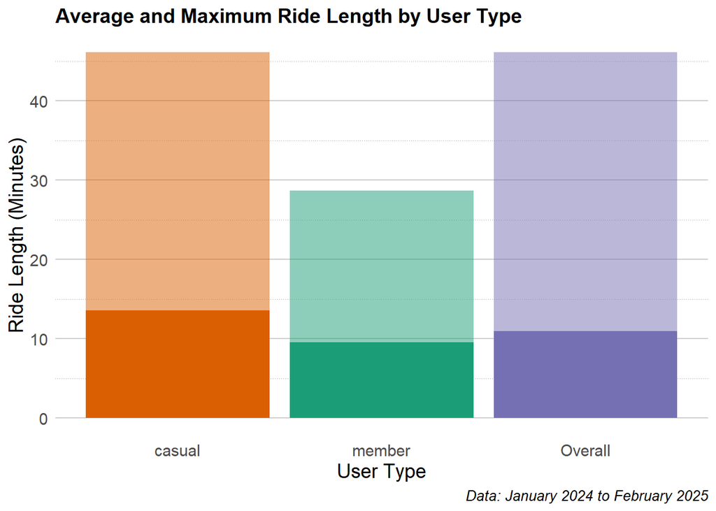

```r
# Set custom colors for the plot
custom_colors <- c("member" = "#1B9E77",  # Green for members
                   "casual" = "#D95F02",  # Orange for casual users
                   "Overall" = "#7570B3")  # Blue for overall

# Create the plot
ggplot(ride_stats, aes(x = member_casual, y = avg_ride_length, fill = member_casual)) +
  geom_bar(stat = "identity", position = "dodge", show.legend = FALSE) +
  geom_bar(data = ride_stats, aes(x = member_casual, y = max_ride_length, fill = member_casual),
           stat = "identity", position = "dodge", alpha = 0.5, show.legend = FALSE) +
  scale_fill_manual(values = custom_colors) +
  labs(
    title = "Average and Maximum Ride Length by User Type",
    x = "User Type",
    y = "Ride Length (Minutes)",
    caption = "Data: January 2024 to February 2025"
  ) +
  custom_theme +
  theme(legend.position = "none")
```

### RIDEABLE TYPE - pie chart -MEMBERS

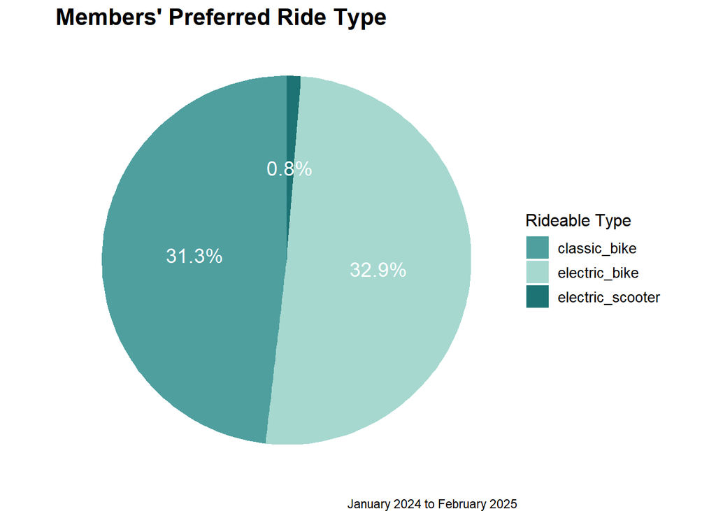

```r
# Calculate the total count of trips by member_casual and rideable_type
df_rideable_count <- df_cleaned_distinct %>%
  group_by(member_casual, rideable_type) %>%
  tally() %>%
  ungroup() %>%
  mutate(percentage = n / sum(n) * 100)  # Calculate the percentage for each group

# Ensure that all rideable types are present for both member and casual
df_rideable_count <- df_rideable_count %>%
  complete(member_casual, rideable_type, fill = list(n = 0, percentage = 0))  # Fill missing combinations

# Define shades of teal for members (lighter to darker shades)
teal_colors <- c("electric_bike" = "#A6D8D0", "classic_bike" = "#4F9F9F", "electric_scooter" = "#1D7373")

# Separate data for members
df_members <- df_rideable_count %>% filter(member_casual == "member")

# Create the pie chart for members with rideable type labeled with percentage
ggplot(df_members, aes(x = "", y = n, fill = rideable_type)) +
  geom_bar(stat = "identity", width = 1) +
  coord_polar(theta = "y") +  # Convert to pie chart
  scale_fill_manual(values = teal_colors) +  # Use the shades of teal
  geom_text(aes(label = paste0(round(percentage, 1), "%")),
            position = position_stack(vjust = 0.5), color = "white", size = 5) +  # Add percentage labels inside pie
  labs(title = "Members' Preferred Ride Type",
       caption = "January 2024 to February 2025",
       fill = "Rideable Type") +
  theme_void() +  # Clean up the chart
  theme(
    legend.position = "right",  # Move the legend to the side
    legend.title = element_text(size = 12),
    legend.text = element_text(size = 10),
    plot.title = element_text(size = 16, face = "bold")
  )
```

#### RIDEABLE TYPE - pie chart -CASUALS

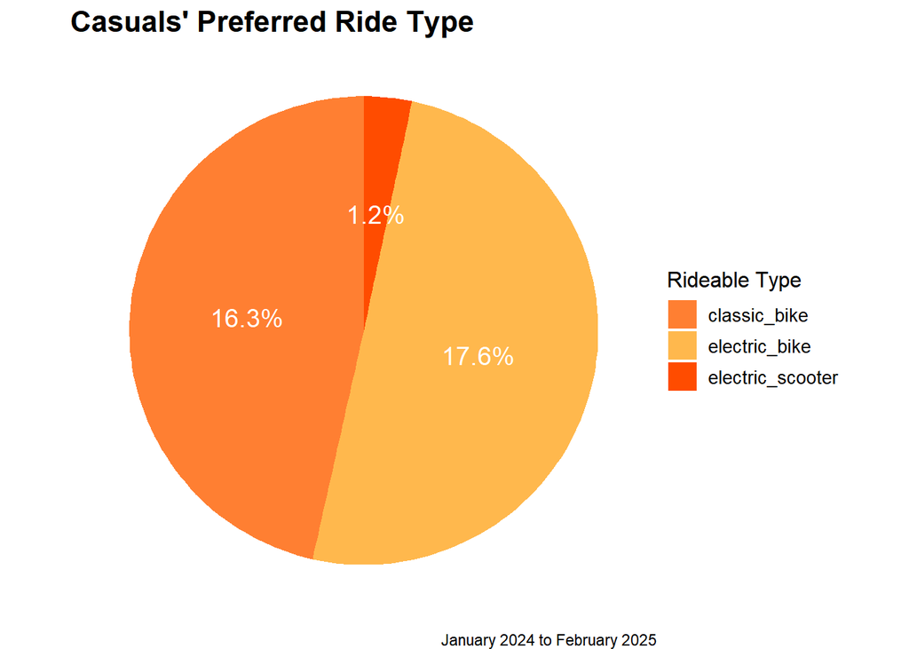

```r
# Define shades of orange for casuals (lighter to darker shades)
orange_colors <- c("electric_bike" = "#FFB84D", "classic_bike" = "#FF7F32", "electric_scooter" = "#FF4C00")

# Separate data for casuals
df_casuals <- df_rideable_count %>% filter(member_casual == "casual")

# Create the pie chart for casuals with rideable type labeled with percentage
ggplot(df_casuals, aes(x = "", y = n, fill = rideable_type)) +
  geom_bar(stat = "identity", width = 1) +
  coord_polar(theta = "y") +  # Convert to pie chart
  scale_fill_manual(values = orange_colors) +  # Use the shades of orange
  geom_text(aes(label = paste0(round(percentage, 1), "%")),
            position = position_stack(vjust = 0.5), color = "white", size = 5) +  # Add percentage labels inside pie
  labs(title = "Casuals' Preferred Ride Type",
       caption = "January 2024 to February 2025",
       fill = "Rideable Type") +
  theme_void() +  # Clean up the chart
  theme(
    legend.position = "right",  # Move the legend to the side
    legend.title = element_text(size = 12),
    legend.text = element_text(size = 10),
    plot.title = element_text(size = 16, face = "bold")
  )
```

### LOCATION-BASED ANALYSIS

#### TOP 10 start stations -casual

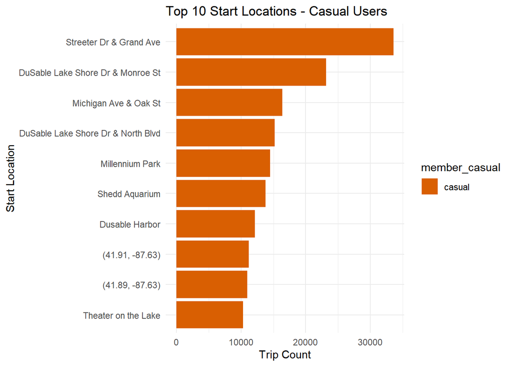

```r
library(dplyr)
library(ggplot2)

# Count rides by start latitude & longitude (without using station names for counting)
top_start_stations <- df_cleaned_distinct %>%
  group_by(member_casual, start_lat, start_lng) %>%
  summarise(trip_count = n(), .groups = "drop") %>%
  arrange(member_casual, desc(trip_count))

# Get top 10 start locations per member type
top_10_members <- top_start_stations %>%
  filter(member_casual == "member") %>%
  slice_max(order_by = trip_count, n = 10)

top_10_casual <- top_start_stations %>%
  filter(member_casual == "casual") %>%
  slice_max(order_by = trip_count, n = 10)

# Merge with original data to get station names (if available)
top_10_members <- top_10_members %>%
  left_join(df_cleaned_distinct %>% select(start_lat, start_lng, start_station_name) %>% distinct(),
            by = c("start_lat", "start_lng"))

top_10_casual <- top_10_casual %>%
  left_join(df_cleaned_distinct %>% select(start_lat, start_lng, start_station_name) %>% distinct(),
            by = c("start_lat", "start_lng"))

# Create display column: Use station name if available, otherwise show GPS coordinates
top_10_members <- top_10_members %>%
  mutate(start_display = ifelse(!is.na(start_station_name), start_station_name, paste0("(", start_lat, ", ", start_lng, ")")))

top_10_casual <- top_10_casual %>%
  mutate(start_display = ifelse(!is.na(start_station_name), start_station_name, paste0("(", start_lat, ", ", start_lng, ")")))

# Sort data to ensure top 1 is at the top for plotting (for both members and casual)
top_10_members <- top_10_members %>%
  arrange(desc(trip_count))

top_10_casual <- top_10_casual %>%
  arrange(desc(trip_count))

# Plot for members
p_member_start <- ggplot(top_10_members, aes(x = trip_count, y = reorder(start_display, trip_count), fill = member_casual)) +
  geom_bar(stat = "identity") +
  labs(title = "Top 10 Start Locations - Members", x = "Trip Count", y = "Start Location") +
  scale_fill_manual(values = c("member" = "#1B9E77")) +
  theme_minimal()

# Plot for casual users
p_casual_start <- ggplot(top_10_casual, aes(x = trip_count, y = reorder(start_display, trip_count), fill = member_casual)) +
  geom_bar(stat = "identity") +
  labs(title = "Top 10 Start Locations - Casual Users", x = "Trip Count", y = "Start Location") +
  scale_fill_manual(values = c("casual" = "#D95F02")) +
  theme_minimal()

# Print plots
print(p_casual_start)
```

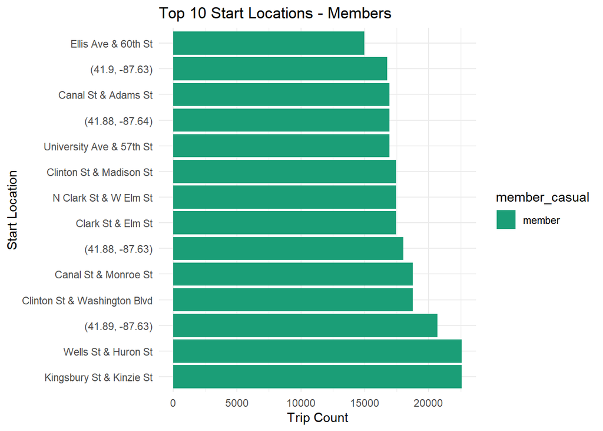

```r
library(dplyr)
library(ggplot2)

# Count rides by start latitude & longitude (without using station names for counting)
top_start_stations <- df_cleaned_distinct %>%
  group_by(member_casual, start_lat, start_lng) %>%
  summarise(trip_count = n(), .groups = "drop") %>%
  arrange(member_casual, desc(trip_count))

# Get top 10 start locations for members
top_10_members <- top_start_stations %>%
  filter(member_casual == "member") %>%
  slice_max(order_by = trip_count, n = 10)

# Merge with original data to get station names (if available)
top_10_members <- top_10_members %>%
  left_join(df_cleaned_distinct %>% select(start_lat, start_lng, start_station_name) %>% distinct(),
            by = c("start_lat", "start_lng"))

# Create display column: Use station name if available, otherwise show GPS coordinates
top_10_members <- top_10_members %>%
  mutate(start_display = ifelse(!is.na(start_station_name), start_station_name, paste0("(", start_lat, ", ", start_lng, ")")))

# Ensure no duplicates in the final top 10, keeping only the highest trip count for each location
top_10_members <- top_10_members %>%
  distinct(start_display, .keep_all = TRUE)  # This ensures unique start_display values

# Sort the data by trip_count in descending order
top_10_members <- top_10_members %>%
  arrange(desc(trip_count))

# Convert start_display to a factor with levels in the order of trip_count
top_10_members$start_display <- factor(top_10_members$start_display,
                                       levels = top_10_members$start_display)

# Plot for members (now ordered correctly)
p_member_start <- ggplot(top_10_members, aes(x = trip_count, y = start_display, fill = member_casual)) +
  geom_bar(stat = "identity") +
  labs(title = "Top 10 Start Locations - Members", x = "Trip Count", y = "Start Location") +
  scale_fill_manual(values = c("member" = "#1B9E77")) +
  theme_minimal()

# Print the plot for members
print(p_member_start)
```

#### TOP 10 end stations -casual

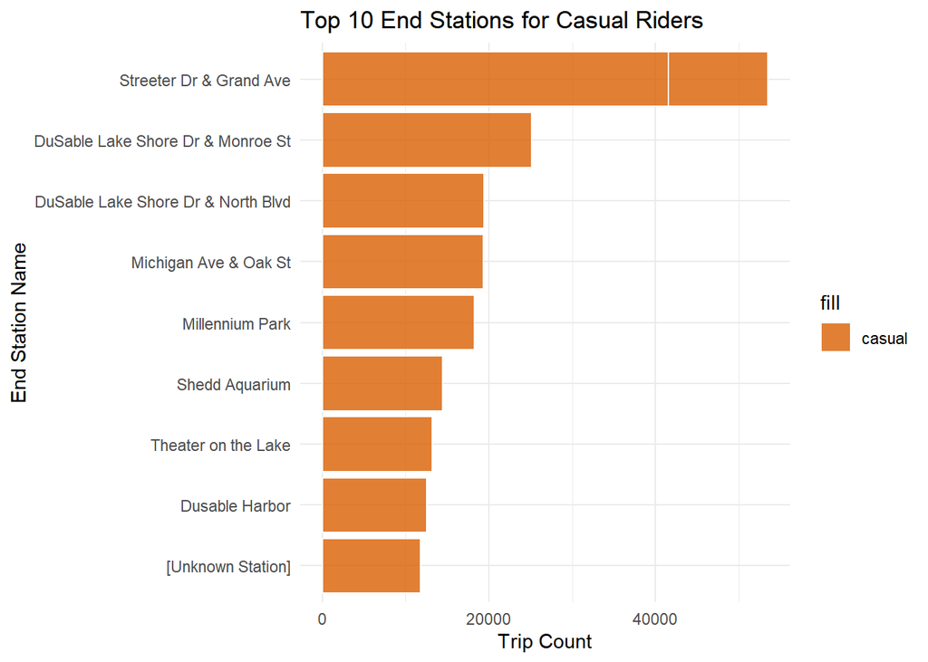

```r
library(dplyr)
library(ggplot2)

# Function to get top 10 end stations for a given rider type
get_top_end_stations <- function(df_cleaned_distinct, rider_type) {
  df_cleaned_distinct %>%
    filter(member_casual == rider_type) %>%
    group_by(end_lat, end_lng) %>%
    summarise(count = n(), .groups = "drop") %>%
    arrange(desc(count)) %>%
    slice_head(n = 10) %>%  # Get top 10
    left_join(df_cleaned_distinct %>% select(end_lat, end_lng, end_station_name) %>% distinct(),
              by = c("end_lat", "end_lng")) %>%
    mutate(end_station_name = ifelse(is.na(end_station_name), "[Unknown Station]", end_station_name))
}

# Get top 10 end stations for members and casual riders
top_end_stations_member <- get_top_end_stations(df_cleaned_distinct, "member")
top_end_stations_casual <- get_top_end_stations(df_cleaned_distinct, "casual")

# Plot for casual riders
ggplot(top_end_stations_casual, aes(x = count, y = reorder(end_station_name, count), fill = "casual")) +
  geom_bar(stat = "identity", color = "white", alpha = 0.8) +
  scale_fill_manual(values = c("casual" = "#D95F02")) +
  labs(title = "Top 10 End Stations for Casual Riders",
       x = "Trip Count",
       y = "End Station Name") +
  theme_minimal()
```

```r
print("Top 10 End Stations for Casual Riders")
```

```
## [1] "Top 10 End Stations for Casual Riders"
```

```r
print(top_end_stations_casual)
```

```
## # A tibble: 10 × 4
##    end_lat end_lng count end_station_name
##      <dbl>   <dbl> <int> <chr>
##  1    41.9   -87.6 41521 Streeter Dr & Grand Ave
##  2    41.9   -87.6 25134 DuSable Lake Shore Dr & Monroe St
##  3    41.9   -87.6 19442 DuSable Lake Shore Dr & North Blvd
##  4    41.9   -87.6 19326 Michigan Ave & Oak St
##  5    41.9   -87.6 18280 Millennium Park
##  6    41.9   -87.6 14476 Shedd Aquarium
##  7    41.9   -87.6 13218 Theater on the Lake
##  8    41.9   -87.6 12574 Dusable Harbor
##  9    41.9   -87.6 11930 Streeter Dr & Grand Ave
## 10    41.9   -87.6 11787 [Unknown Station]
```

#### TOP 10 end stations -member& casual

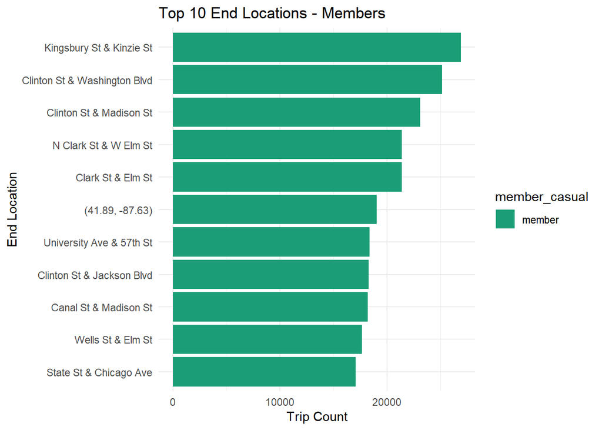

```r
library(dplyr)
library(ggplot2)

# Count rides by end latitude & longitude (without using station names for counting)
top_end_stations <- df_cleaned_distinct %>%
  group_by(member_casual, end_lat, end_lng) %>%
  summarise(trip_count = n(), .groups = "drop") %>%
  arrange(member_casual, desc(trip_count))

# Get top 10 end locations for members
top_10_members_end <- top_end_stations %>%
  filter(member_casual == "member") %>%
  slice_max(order_by = trip_count, n = 10)

# Get top 10 end locations for casual users
top_10_casual_end <- top_end_stations %>%
  filter(member_casual == "casual") %>%
  slice_max(order_by = trip_count, n = 10)

# Merge with original data to get station names (if available)
top_10_members_end <- top_10_members_end %>%
  left_join(df_cleaned_distinct %>% select(end_lat, end_lng, end_station_name) %>% distinct(),
            by = c("end_lat", "end_lng"))

top_10_casual_end <- top_10_casual_end %>%
  left_join(df_cleaned_distinct %>% select(end_lat, end_lng, end_station_name) %>% distinct(),
            by = c("end_lat", "end_lng"))

# Create display column: Use station name if available, otherwise show GPS coordinates
top_10_members_end <- top_10_members_end %>%
  mutate(end_display = ifelse(!is.na(end_station_name), end_station_name, paste0("(", end_lat, ", ", end_lng, ")")))

top_10_casual_end <- top_10_casual_end %>%
  mutate(end_display = ifelse(!is.na(end_station_name), end_station_name, paste0("(", end_lat, ", ", end_lng, ")")))

# Ensure no duplicates in the final top 10, keeping only the highest trip count for each location
top_10_members_end <- top_10_members_end %>%
  distinct(end_display, .keep_all = TRUE)

top_10_casual_end <- top_10_casual_end %>%
  distinct(end_display, .keep_all = TRUE)

# Sort the data by trip_count in ascending order (reversed from the previous sorting)
top_10_members_end <- top_10_members_end %>%
  arrange(trip_count)  # Sorted ascending

top_10_casual_end <- top_10_casual_end %>%
  arrange(trip_count)  # Sorted ascending

# Convert end_display to a factor with levels in the order of trip_count (ascending)
top_10_members_end$end_display <- factor(top_10_members_end$end_display,
                                         levels = top_10_members_end$end_display)

top_10_casual_end$end_display <- factor(top_10_casual_end$end_display,
                                         levels = top_10_casual_end$end_display)

# Plot for members (end stations) - reversed order
p_member_end <- ggplot(top_10_members_end, aes(x = trip_count, y = end_display, fill = member_casual)) +
  geom_bar(stat = "identity") +
  labs(title = "Top 10 End Locations - Members", x = "Trip Count", y = "End Location") +
  scale_fill_manual(values = c("member" = "#1B9E77")) +
  theme_minimal()

# Plot for casual users (end stations) - reversed order
p_casual_end <- ggplot(top_10_casual_end, aes(x = trip_count, y = end_display, fill = member_casual)) +
  geom_bar(stat = "identity") +
  labs(title = "Top 10 End Locations - Casual Users", x = "Trip Count", y = "End Location") +
  scale_fill_manual(values = c("casual" = "#D95F02")) +
  theme_minimal()

# Print the plots for members and casual users (end stations) - reversed order
print(p_member_end)
```

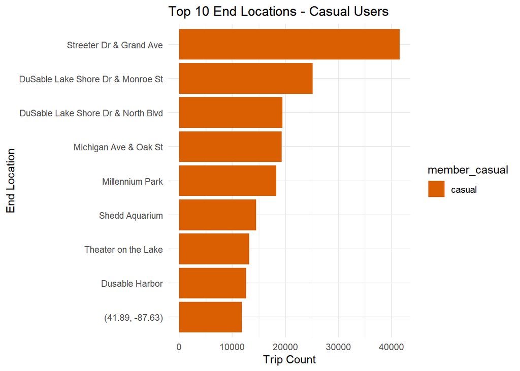

```r
print(p_casual_end)
```

#### TOP 10 STATION PAIRS -casual & member

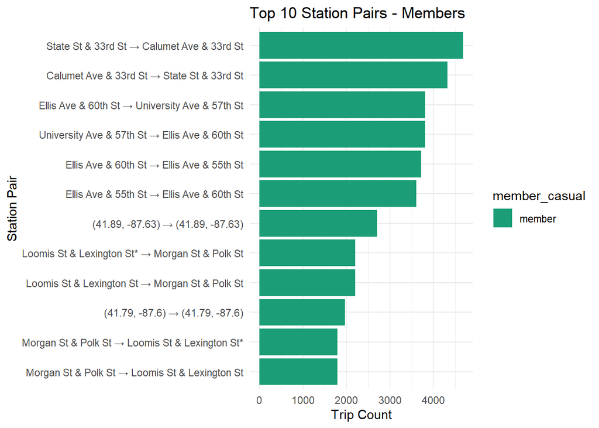

```r
library(dplyr)
library(ggplot2)

# Step 1: Create a lookup table for station names based on exact GPS coordinates
station_lookup <- df_cleaned_distinct %>%
  select(start_lat, start_lng, start_station_name, end_lat, end_lng, end_station_name) %>%
  distinct()

# Step 2: Count trips based on exact GPS coordinates
top_station_pairs_gps <- df_cleaned_distinct %>%
  group_by(member_casual, start_lat, start_lng, end_lat, end_lng) %>%
  summarise(trip_count = n(), .groups = "drop") %>%
  arrange(member_casual, desc(trip_count))

# Step 3: Get the top 5 station pairs for each member type
top_10_members <- top_station_pairs_gps %>% filter(member_casual == "member") %>% slice_max(order_by = trip_count, n = 10)
top_10_casual <- top_station_pairs_gps %>% filter(member_casual == "casual") %>% slice_max(order_by = trip_count, n = 10)

# Step 4: Merge with station names (Exact Match)
top_10_members <- top_10_members %>%
  left_join(station_lookup, by = c("start_lat", "start_lng", "end_lat", "end_lng")) %>%
  mutate(
    station_pair_display = ifelse(!is.na(start_station_name) & !is.na(end_station_name),
                                  paste(start_station_name, "→", end_station_name),
                                  paste0("(", start_lat, ", ", start_lng, ") → (", end_lat, ", ", end_lng, ")"))
  )

top_10_casual <- top_10_casual %>%
  left_join(station_lookup, by = c("start_lat", "start_lng", "end_lat", "end_lng")) %>%
  mutate(
    station_pair_display = ifelse(!is.na(start_station_name) & !is.na(end_station_name),
                                  paste(start_station_name, "→", end_station_name),
                                  paste0("(", start_lat, ", ", start_lng, ") → (", end_lat, ", ", end_lng, ")"))
  )

# Step 5: Plot for members
p_member <- ggplot(top_10_members, aes(x = trip_count, y = reorder(station_pair_display, trip_count), fill = member_casual)) +
  geom_bar(stat = "identity") +
  labs(title = "Top 10 Station Pairs - Members", x = "Trip Count", y = "Station Pair") +
  scale_fill_manual(values = c("member" = "#1B9E77")) +
  theme_minimal()

# Step 6: Plot for casual users
p_casual <- ggplot(top_10_casual, aes(x = trip_count, y = reorder(station_pair_display, trip_count), fill = member_casual)) +
  geom_bar(stat = "identity") +
  labs(title = "Top 10 Station Pairs - Casual Users", x = "Trip Count", y = "Station Pair") +
  scale_fill_manual(values = c("casual" = "#D95F02")) +
  theme_minimal()

# Print plots
print(p_member) # delete print casual so member printed first
```

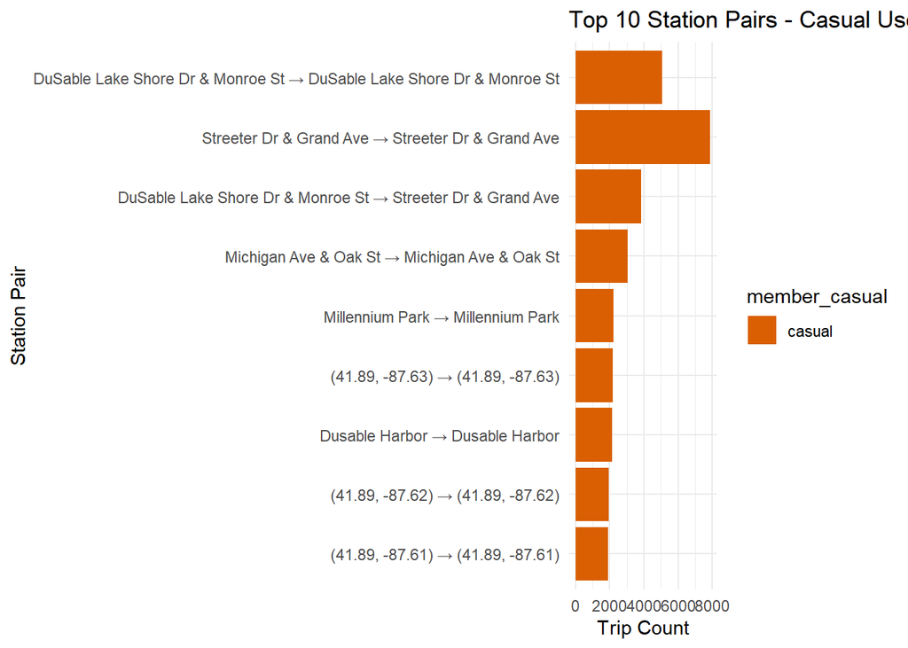

```r
print(p_casual) #copy paste whole code and print casual
```